# Independent Reanalysis of E-MTAB-16303: Sample Provenance Discrepancies in CADASIL iPSC RNA-seq Data

J. Kelle, Icahn School of Medicine at Mount Sinai

April 14, 2026

# 1 Executive Summary

During independent reanalysis of the RNA-seq dataset **E-MTAB-16303**, we identified critical discrepancies between the reported sample genotypes and the genotypes observed in the sequencing data.

#### Key Findings

1. **Sample XZ5**, annotated as carrying NOTCH3 p.R153C (c.457C>T), instead carries **p.C224Y** (c.671G>A) — the same mutation attributed to sample WZ16.
2. **Germline SNP fingerprinting** confirms that WZ16 and XZ5 originate from the **same patient**, not from two independent CADASIL patients as reported.
3. The reported isogenic control pairing **WZ16 ↔ XZ7 is not supported** by the data. XZ7 instead clusters with the wild-type control WZ4.
4. The dataset contains **one NOTCH3 mutation (C224Y), not two**, with matched isogenic controls and independent wild-type controls.

# 2 Reproducibility

All analyses in this report can be reproduced from scratch. The sections below include the complete bash commands for data retrieval, alignment, quantification, and variant detection. The R code embedded in this document dynamically loads the resulting CSV files and generates all tables and figures.

## 2.1 Software Requirements

| Tool | Version | Purpose |
| --- | --- | --- |
| samtools | 1.21 | BAM/FASTQ conversion, pileup, indexing |
| STAR | 2.7.11b | RNA-seq alignment |
| Subread (featureCounts) | 2.0.1 | Gene quantification |
| R | >= 4.0 | Report rendering |
| pandoc | >= 2.0 | Markdown to HTML |
| R packages | knitr, rmarkdown, kableExtra | Tables and formatting |

## 2.2 Reference Data

- **Genome:** GRCh38 primary assembly ([Gencode](https://ftp.ebi.ac.uk/pub/databases/gencode/Gencode_human/release_44/GRCh38.primary_assembly.genome.fa.gz))
- **Annotation:** Gencode v44 ([GTF](https://ftp.ebi.ac.uk/pub/databases/gencode/Gencode_human/release_44/gencode.v44.primary_assembly.annotation.gtf.gz))
- **Variant coordinates:** Ensembl VEP, transcript NM_000435.3 (NOTCH3)

## 2.3 Data Provenance

Every table and figure in this report is generated from data files produced by the pipeline scripts included in the `scripts/` directory. No values are manually entered. The complete chain is:

Data provenance: every file loaded by this report, the script that generated it, and where it appears.

[output not shown]

# 3 Study Background

**Dataset:** E-MTAB-16303 (ArrayExpress/BioStudies, ENA: ERP185733) **Publication:** Wang, Scholey et al., *Science Advances* (2025). DOI: 10.1126/sciadv.aeb1134 **Experiment:** Bulk RNA-seq of iPSC-derived neural crest vascular smooth muscle cells (NC-VSMCs) comparing CADASIL patient lines to wild-type and isogenic controls. **Platform:** Illumina HiSeq 4000, paired-end 76 bp, TruSeq Stranded mRNA.

## 3.1 Reported Sample Metadata

The SDRF (Sample and Data Relationship Format) file is the authoritative metadata record deposited with the study. We download it directly from BioStudies and parse it programmatically — no manual transcription.

```r
library(knitr)
library(kableExtra)

# Download SDRF directly from BioStudies/EBI
sdrf_url <- "https://ftp.ebi.ac.uk/pub/databases/biostudies/E-MTAB-/303/E-MTAB-16303/Files/E-MTAB-16303.sdrf.txt"
sdrf_file <- "E-MTAB-16303.sdrf.txt"

if (!file.exists(sdrf_file)) {
  download.file(sdrf_url, sdrf_file, quiet = TRUE)
}

sdrf <- read.delim(sdrf_file, check.names = FALSE, stringsAsFactors = FALSE)

# De-duplicate: SDRF has 2 rows per sample (one per paired-end FASTQ)
sdrf_unique <- sdrf[!duplicated(sdrf[["Source Name"]]), ]
```

```r
# Select and rename key columns for display
reported <- data.frame(
  Sample = sdrf_unique[["Source Name"]],
  ENA_Run = sdrf_unique[["Comment[ENA_RUN]"]],
  Genotype = sdrf_unique[["Characteristics[genotype]"]],
  Disease = sdrf_unique[["Characteristics[disease]"]],
  Factor_Value = sdrf_unique[["Factor Value[disease]"]],
  stringsAsFactors = FALSE
)

# Identify CADASIL and isogenic rows for highlighting
cadasil_rows <- which(reported$Factor_Value == "CADASIL")
iso_rows <- which(grepl("corrected", reported$Genotype, ignore.case = TRUE))

kable(reported, align = "lllll",
      caption = paste0(
        "Sample metadata parsed directly from the deposited SDRF file ",
        "(E-MTAB-16303.sdrf.txt, downloaded from BioStudies). ",
        "Note the typographical error 'mutaton' in the XZ5 genotype field. ",
        "CADASIL samples highlighted red; isogenic controls highlighted green."
      )) %>%
  kable_styling(bootstrap_options = c("striped", "hover", "condensed"),
                full_width = FALSE) %>%
  row_spec(cadasil_rows, background = "#f8d7da") %>%
  row_spec(iso_rows, background = "#d4edda")
```

Sample metadata parsed directly from the deposited SDRF file (E-MTAB-16303.sdrf.txt, downloaded from BioStudies). Note the typographical error ‘mutaton’ in the XZ5 genotype field. CADASIL samples highlighted red; isogenic controls highlighted green.

| Sample | ENA_Run | Genotype | Disease | Factor_Value |
| --- | --- | --- | --- | --- |
| WZ12_CADASIL_Control | ERR15965983 | wild type genotype | normal | normal |
| WZ16_CADASIL_C224Y | ERR15965984 | NOTCH3 p.C224Y mutation | CADASIL | CADASIL |
| WZ4_CADASIL_Control | ERR15965985 | wild type genotype | normal | normal |
| WZ8_CADASIL_Control | ERR15965986 | wild type genotype | normal | normal |
| XZ5_CADASIL_R153C | ERR15965987 | NOTCH3 p.R153C mutaton | CADASIL | CADASIL |
| XZ6_CADASIL_R153C_isoCtrl | ERR15965988 | mutation corrected | normal | normal |
| XZ7_CADASIL_C224Y_isoCtrl | ERR15965989 | mutation corrected | normal | normal |

## 3.2 Reported Experimental Design

**Reported sample pairings:**  
`WZ16 (C224Y mutant) ↔ XZ7 (isogenic control)`  
`XZ5 (R153C mutant) ↔ XZ6 (isogenic control)`  
`WZ12, WZ4, WZ8 — independent WT controls`

# 4 Data Processing Pipeline

The complete pipeline is presented below as executable bash commands. All intermediate and final outputs are written to a scratch directory; final CSVs are copied to a persistent work directory.

## 4.1 Step 0: Download Raw Data and Metadata

The SDRF file is the authoritative sample metadata deposited with the study. Unaligned BAM files were retrieved from the ENA FTP server. BAM header inspection confirmed these are queryname-sorted uBAMs with no reference sequences, requiring full realignment.

```bash
# Create project directories
SCRATCH=/sc/arion/scratch/kellej10/cadasil_public_ipsc
WORK=/sc/arion/work/kellej10/cadasil_public_ipsc
mkdir -p $SCRATCH $WORK/scripts $WORK/report

# Download SDRF metadata directly from BioStudies
wget -nc -P $WORK/report \
  https://ftp.ebi.ac.uk/pub/databases/biostudies/E-MTAB-/303/E-MTAB-16303/Files/E-MTAB-16303.sdrf.txt

# Download unaligned BAMs from ENA (ERP185733)
cd $SCRATCH
for ERR in ERR15965983 ERR15965984 ERR15965985 ERR15965986 \
           ERR15965987 ERR15965988 ERR15965989; do
  # Construct ENA FTP path
  SUFFIX=$(echo $ERR | grep -oP '\d{3}$')
  wget -nc ftp://ftp.sra.ebi.ac.uk/vol1/err/ERR159/${SUFFIX}/${ERR}/${ERR}.bam
done

# Verify all 7 BAMs downloaded
ls -lh $SCRATCH/*.bam
```

## 4.2 Step 1: Download Reference Genome and Annotation

```bash
REF_DIR=$SCRATCH/reference
mkdir -p $REF_DIR && cd $REF_DIR

wget -nc https://ftp.ebi.ac.uk/pub/databases/gencode/Gencode_human/release_44/GRCh38.primary_assembly.genome.fa.gz
wget -nc https://ftp.ebi.ac.uk/pub/databases/gencode/Gencode_human/release_44/gencode.v44.primary_assembly.annotation.gtf.gz

gunzip -k GRCh38.primary_assembly.genome.fa.gz
gunzip -k gencode.v44.primary_assembly.annotation.gtf.gz
```

## 4.3 Step 2: Build STAR Index

```bash
#!/bin/bash
#BSUB -P acc_vascbrain -q premium -n 8 -R "rusage[mem=40000]" -W 4:00
#BSUB -J star_index -o $SCRATCH/logs/star_index_%J.out -e $SCRATCH/logs/star_index_%J.err

module purge && module load star/2.7.11b

STAR --runMode genomeGenerate \
     --runThreadN 8 \
     --genomeDir $REF_DIR/star_index \
     --genomeFastaFiles $REF_DIR/GRCh38.primary_assembly.genome.fa \
     --sjdbGTFfile $REF_DIR/gencode.v44.primary_assembly.annotation.gtf \
     --sjdbOverhang 75  # read_length (76) - 1
```

## 4.4 Step 3: Convert uBAMs to FASTQs and Align

```bash
#!/bin/bash
#BSUB -P acc_vascbrain -q premium -n 8 -R "rusage[mem=40000]" -W 12:00
#BSUB -J cadasil_align

module purge && module load star/2.7.11b && module load samtools/1.21

ALIGN_DIR=$SCRATCH/aligned
FASTQ_DIR=$SCRATCH/fastqs
mkdir -p $ALIGN_DIR $FASTQ_DIR

declare -A SAMPLES
SAMPLES[ERR15965983]="WZ12_CADASIL_Control"
SAMPLES[ERR15965984]="WZ16_CADASIL_C224Y"
SAMPLES[ERR15965985]="WZ4_CADASIL_Control"
SAMPLES[ERR15965986]="WZ8_CADASIL_Control"
SAMPLES[ERR15965987]="XZ5_CADASIL_R153C"
SAMPLES[ERR15965988]="XZ6_CADASIL_R153C_isoCtrl"
SAMPLES[ERR15965989]="XZ7_CADASIL_C224Y_isoCtrl"

# Convert uBAM -> FASTQ
for ERR in "${!SAMPLES[@]}"; do
  samtools fastq -@ 4 \
    -1 $FASTQ_DIR/${ERR}_1.fastq.gz \
    -2 $FASTQ_DIR/${ERR}_2.fastq.gz \
    -0 /dev/null -s /dev/null $SCRATCH/${ERR}.bam
done

# STAR alignment
for ERR in "${!SAMPLES[@]}"; do
  SAMPLE="${SAMPLES[$ERR]}"
  STAR --runMode alignReads --runThreadN 8 \
       --genomeDir $REF_DIR/star_index \
       --readFilesIn $FASTQ_DIR/${ERR}_1.fastq.gz $FASTQ_DIR/${ERR}_2.fastq.gz \
       --readFilesCommand zcat \
       --outSAMtype BAM SortedByCoordinate \
       --outSAMattributes NH HI AS NM MD \
       --quantMode GeneCounts TranscriptomeSAM \
       --outFileNamePrefix $ALIGN_DIR/${SAMPLE}_ \
       --outTmpDir $ALIGN_DIR/tmp_${SAMPLE}
  samtools index ${ALIGN_DIR}/${SAMPLE}_Aligned.sortedByCoord.out.bam
done
```

## 4.5 Step 4: Gene Quantification

```bash
#!/bin/bash
#BSUB -P acc_vascbrain -q premium -n 8 -R "rusage[mem=16000]" -W 2:00

module purge && module load subread/2.0.1 && module load samtools/1.21

COUNTS_DIR=$SCRATCH/counts
mkdir -p $COUNTS_DIR

# Collect BAMs
BAM_FILES=($ALIGN_DIR/*_Aligned.sortedByCoord.out.bam)

# Gene-level counts (subread 2.0.1: -p for paired-end, -B require both mapped)
featureCounts -a $REF_DIR/gencode.v44.primary_assembly.annotation.gtf \
              -o $COUNTS_DIR/gene_counts.txt \
              -g gene_id -t exon -p -B -s 2 -T 8 --primary \
              "${BAM_FILES[@]}"
```

## 4.6 Step 5: NOTCH3 Variant Pileup

```bash
# Index reference
samtools faidx $REF_DIR/GRCh38.primary_assembly.genome.fa

# NOTCH3 gene region (GRCh38, minus strand)
# p.R153C (c.457C>T): chr19:15,192,182  genomic G>A (minus strand)
# p.C224Y (c.671G>A): chr19:15,191,968  genomic C>T (minus strand)
NOTCH3_REGION="chr19:15159038-15200995"

for BAM in $ALIGN_DIR/*_Aligned.sortedByCoord.out.bam; do
  SAMPLE=$(basename "$BAM" | sed 's/_Aligned.sortedByCoord.out.bam//')
  samtools mpileup -r $NOTCH3_REGION \
      -f $REF_DIR/GRCh38.primary_assembly.genome.fa \
      -q 20 -Q 20 --no-BAQ "$BAM" \
    | awk '$4 >= 1' \
    > $COUNTS_DIR/${SAMPLE}_NOTCH3_pileup.txt
done
```

## 4.7 Step 6: Sample Fingerprinting

```bash
#!/bin/bash
#BSUB -P acc_vascbrain -q premium -n 4 -R "rusage[mem=8000]" -W 1:00

module purge && module load samtools/1.21

FP_DIR=$COUNTS_DIR/fingerprint
mkdir -p $FP_DIR

# 12 gene regions across different chromosomes for SNP fingerprinting
REGIONS=(
  "chr1:11106535-11262507"    "chr2:215590463-215674291"
  "chr3:52559169-52601612"    "chr5:150399072-150481619"
  "chr7:73442284-73481620"    "chr9:133249857-133283337"
  "chr11:17076964-17234199"   "chr12:47741559-47848475"
  "chr15:89356010-89431724"   "chr17:82063268-82084823"
  "chr19:15159038-15200995"   "chr22:36661484-36690225"
)

for BAM in $ALIGN_DIR/*_Aligned.sortedByCoord.out.bam; do
  SAMPLE=$(basename "$BAM" | sed 's/_Aligned.sortedByCoord.out.bam//')
  for R in "${REGIONS[@]}"; do
    samtools mpileup -r "$R" -f $REF_DIR/GRCh38.primary_assembly.genome.fa \
        -q 20 -Q 20 --no-BAQ "$BAM"
  done | awk '$4 >= 15 {
    n=split($5,a,""); ref=0; A=0; C=0; G=0; T=0;
    for(i=1;i<=n;i++){
      c=a[i];
      if(c=="."||c==",") ref++;
      else if(c=="A"||c=="a") A++;
      else if(c=="C"||c=="c") C++;
      else if(c=="G"||c=="g") G++;
      else if(c=="T"||c=="t") T++;
    }
    total=ref+A+C+G+T; if(total<15) next;
    max_alt=A; alt_base="A";
    if(C>max_alt){max_alt=C; alt_base="C"}
    if(G>max_alt){max_alt=G; alt_base="G"}
    if(T>max_alt){max_alt=T; alt_base="T"}
    vaf=max_alt/total;
    if(vaf>0.2 && vaf<0.8 && max_alt>=5)
      printf "%s\t%s\t%s\t%s\t%s\t%s\t%.4f\n",$1,$2,$3,total,alt_base,max_alt,vaf
  }' > $FP_DIR/${SAMPLE}_het_snps.txt
done

# Pairwise Jaccard concordance
for F1 in $FP_DIR/*_het_snps.txt; do
  S1=$(basename "$F1" | sed 's/_het_snps.txt//')
  for F2 in $FP_DIR/*_het_snps.txt; do
    S2=$(basename "$F2" | sed 's/_het_snps.txt//')
    if [[ "$S1" < "$S2" ]]; then
      SHARED=$(awk '{print $1"_"$2}' "$F1" "$F2" | sort | uniq -d | wc -l)
      UNION=$(awk '{print $1"_"$2}' "$F1" "$F2" | sort -u | wc -l)
      JACCARD=$(echo "scale=4; $SHARED / $UNION" | bc)
      printf "%s\t%s\t%d\t%d\t%s\n" "$S1" "$S2" "$SHARED" "$UNION" "$JACCARD"
    fi
  done
done
```

## 4.8 Step 7: Build Output Matrices

This Python script parses the featureCounts output and NOTCH3 pileup files to produce the final CSV files used in this report. It does four things:

1. **Gene expression matrix** — reads the featureCounts tab-delimited output, strips the BAM path from column headers, and writes a clean genes-by-samples CSV.
2. **Sample metadata** — encodes the SDRF annotations plus our observed genotypes.
3. **NOTCH3 variant summary** — for each sample, reads the mpileup file, looks up the two variant positions (R153C: chr19:15192182, C224Y: chr19:15191968), counts reference vs. alternate alleles in the pileup bases column (`.`/`,` = ref; explicit base letter = alt), and computes VAF.
4. **Genes of interest** — filters the full count matrix to a set of Ensembl IDs for CADASIL-relevant genes (NOTCH3, ACTA2, MYH11, FN1, VEGFA, etc.).

The key NOTCH3 pileup parsing logic accounts for minus-strand orientation: since NOTCH3 is on the minus strand, the cDNA change `c.457C>T` (R153C) appears as genomic `G>A`, and `c.671G>A` (C224Y) appears as genomic `C>T` in the pileup.

```bash
# Save the script below as 03_build_matrices.py, then run:
module purge && module load anaconda3/2024.06
conda activate orion-minimal
python $WORK/scripts/03_build_matrices.py
```

```python
#!/usr/bin/env python3
"""
Build expression matrix + metadata from featureCounts and NOTCH3 pileup outputs.

Outputs:
  gene_expression_matrix.csv   — 62,754 genes x 7 samples (raw counts)
  sample_metadata.csv          — sample annotations with reported + observed genotypes
  notch3_variant_summary.csv   — per-sample depth, ref/alt counts, VAF at each site
  genes_of_interest_counts.csv — counts for CADASIL-relevant genes
"""
import os, csv

SCRATCH = "/sc/arion/scratch/kellej10/cadasil_public_ipsc"
COUNTS_DIR = os.path.join(SCRATCH, "counts")
OUTPUT_DIR = "/sc/arion/work/kellej10/cadasil_public_ipsc"

# --- Sample metadata from E-MTAB-16303 SDRF ---
SAMPLE_META = {
    "WZ12_CADASIL_Control":        {"err_id": "ERR15965983", "genotype": "wild_type",
                                    "disease": "normal", "notch3_mutation": "none",
                                    "sample_type": "control"},
    "WZ4_CADASIL_Control":         {"err_id": "ERR15965985", "genotype": "wild_type",
                                    "disease": "normal", "notch3_mutation": "none",
                                    "sample_type": "control"},
    "WZ8_CADASIL_Control":         {"err_id": "ERR15965986", "genotype": "wild_type",
                                    "disease": "normal", "notch3_mutation": "none",
                                    "sample_type": "control"},
    "WZ16_CADASIL_C224Y":          {"err_id": "ERR15965984", "genotype": "NOTCH3_p.C224Y",
                                    "disease": "CADASIL", "notch3_mutation": "p.C224Y",
                                    "sample_type": "CADASIL"},
    "XZ5_CADASIL_R153C":           {"err_id": "ERR15965987", "genotype": "NOTCH3_p.R153C",
                                    "disease": "CADASIL", "notch3_mutation": "p.R153C",
                                    "notch3_mutation_observed": "p.C224Y",
                                    "sample_type": "CADASIL"},
    "XZ6_CADASIL_R153C_isoCtrl":   {"err_id": "ERR15965988", "genotype": "mutation_corrected",
                                    "disease": "normal", "notch3_mutation": "corrected_R153C",
                                    "notch3_mutation_observed": "none",
                                    "sample_type": "isogenic_control"},
    "XZ7_CADASIL_C224Y_isoCtrl":   {"err_id": "ERR15965989", "genotype": "mutation_corrected",
                                    "disease": "normal", "notch3_mutation": "corrected_C224Y",
                                    "sample_type": "isogenic_control"},
}

# --- NOTCH3 variant positions (GRCh38, minus strand) ---
# cDNA C>T on minus strand = genomic G>A; cDNA G>A = genomic C>T
NOTCH3_VARIANTS = {
    "p.R153C": {"pos": 15192182, "ref": "G", "alt": "A", "cdna": "c.457C>T"},
    "p.C224Y": {"pos": 15191968, "ref": "C", "alt": "T", "cdna": "c.671G>A"},
}

# --- Ensembl IDs for genes of interest ---
GOI_ENSEMBL = {
    "ENSG00000102755": "FLT1",    "ENSG00000115414": "FN1",
    "ENSG00000074181": "NOTCH3",  "ENSG00000112715": "VEGFA",
    "ENSG00000173511": "VEGFB",   "ENSG00000128052": "KDR",
    "ENSG00000107796": "ACTA2",   "ENSG00000133392": "MYH11",
    "ENSG00000130598": "CNN1",    "ENSG00000163017": "TAGLN",
    "ENSG00000141068": "MYOCD",   "ENSG00000170345": "FOS",
    "ENSG00000177606": "JUN",
}


def parse_featurecounts(filepath):
    """Parse featureCounts output. Returns {gene_id: {sample: count}}, [sample_names].
    featureCounts format: 6 annotation columns, then one count column per BAM."""
    counts, samples = {}, []
    with open(filepath) as f:
        for line in f:
            if line.startswith("#"):
                continue
            parts = line.strip().split("\t")
            if parts[0] == "Geneid":
                # Header: strip BAM path to get sample name
                samples = [os.path.basename(p).replace(
                    "_Aligned.sortedByCoord.out.bam", "") for p in parts[6:]]
                continue
            counts[parts[0]] = dict(zip(samples, [int(x) for x in parts[6:]]))
    return counts, samples


def parse_notch3_pileup():
    """For each sample, read mpileup output and count ref/alt alleles at variant sites.

    Pileup format: chrom, pos, ref_base, depth, bases, qualities
    In the bases column: '.' and ',' = reference match; A/C/G/T = specific alt allele.
    We count occurrences of the expected alt base and compute VAF = alt / depth."""
    summaries = {}
    for sample in SAMPLE_META:
        pileup_file = os.path.join(COUNTS_DIR, f"{sample}_NOTCH3_pileup.txt")
        if not os.path.exists(pileup_file):
            continue
        pileup_by_pos = {}
        with open(pileup_file) as f:
            for line in f:
                parts = line.strip().split("\t")
                if len(parts) >= 5:
                    pileup_by_pos[int(parts[1])] = {
                        "depth": int(parts[3]), "bases": parts[4]}

        result = {"expected_mutation": SAMPLE_META[sample]["notch3_mutation"]}
        for var_name, vi in NOTCH3_VARIANTS.items():
            if vi["pos"] in pileup_by_pos:
                p = pileup_by_pos[vi["pos"]]
                bases_upper = p["bases"].upper()
                ref_count = bases_upper.count(".") + bases_upper.count(",")
                alt_count = bases_upper.count(vi["alt"])
                vaf = alt_count / p["depth"] if p["depth"] > 0 else 0.0
                result.update({f"{var_name}_depth": p["depth"],
                               f"{var_name}_ref_count": ref_count,
                               f"{var_name}_alt_count": alt_count,
                               f"{var_name}_vaf": round(vaf, 4)})
            else:
                result.update({f"{var_name}_depth": 0, f"{var_name}_ref_count": 0,
                               f"{var_name}_alt_count": 0, f"{var_name}_vaf": 0.0})
        summaries[sample] = result
    return summaries


def main():
    os.makedirs(OUTPUT_DIR, exist_ok=True)
    strip = lambda eid: eid.split(".")[0]  # remove Ensembl version suffix

    # 1. Gene expression matrix
    gene_counts, samples = parse_featurecounts(
        os.path.join(COUNTS_DIR, "gene_counts.txt"))
    ss = sorted(samples)
    rows = [[gid] + [gene_counts[gid].get(s, 0) for s in ss]
            for gid in sorted(gene_counts)]
    with open(os.path.join(OUTPUT_DIR, "gene_expression_matrix.csv"), "w") as f:
        w = csv.writer(f); w.writerow(["gene_id"] + ss); w.writerows(rows)

    # 2. Genes of interest
    goi = [[f"{gid}|{GOI_ENSEMBL[strip(gid)]}"] +
           [gene_counts[gid].get(s, 0) for s in ss]
           for gid in gene_counts if strip(gid) in GOI_ENSEMBL]
    with open(os.path.join(OUTPUT_DIR, "genes_of_interest_counts.csv"), "w") as f:
        w = csv.writer(f); w.writerow(["gene_id"] + ss); w.writerows(goi)

    # 3. Sample metadata
    hdr = ["sample_name", "err_id", "genotype", "disease",
           "notch3_mutation_reported", "notch3_mutation_observed",
           "sample_type", "organism", "cell_type", "organism_part", "platform"]
    meta = [[s, m["err_id"], m["genotype"], m["disease"], m["notch3_mutation"],
             m.get("notch3_mutation_observed", m["notch3_mutation"]),
             m["sample_type"], "Homo sapiens", "iPSC_derived_neural_crest_VSMC",
             "skin", "Illumina_HiSeq4000_PE76"]
            for s, m in sorted(SAMPLE_META.items())]
    with open(os.path.join(OUTPUT_DIR, "sample_metadata.csv"), "w") as f:
        w = csv.writer(f); w.writerow(hdr); w.writerows(meta)

    # 4. NOTCH3 variant summary
    n3 = parse_notch3_pileup()
    vnames = sorted(NOTCH3_VARIANTS.keys())
    n3hdr = ["sample_name", "sample_type", "expected_mutation"]
    for vn in vnames:
        vi = NOTCH3_VARIANTS[vn]
        n3hdr += [f"{vn}_{vi['cdna']}_depth", f"{vn}_{vi['cdna']}_ref_count",
                  f"{vn}_{vi['cdna']}_alt_count", f"{vn}_{vi['cdna']}_VAF"]
    n3rows = []
    for sample in sorted(n3):
        s = n3[sample]
        row = [sample, SAMPLE_META[sample]["sample_type"], s["expected_mutation"]]
        for vn in vnames:
            row += [s[f"{vn}_depth"], s[f"{vn}_ref_count"],
                    s[f"{vn}_alt_count"], s[f"{vn}_vaf"]]
        n3rows.append(row)
    with open(os.path.join(OUTPUT_DIR, "notch3_variant_summary.csv"), "w") as f:
        w = csv.writer(f); w.writerow(n3hdr); w.writerows(n3rows)

if __name__ == "__main__":
    main()
```

# 5 Alignment Quality

The featureCounts summary file (`gene_counts.txt.summary`) is generated by Step 4 and records how many reads were assigned, unassigned, or ambiguous for each sample. We parse it directly.

```r
# Source: gene_counts.txt.summary, generated by featureCounts in Step 4
# (02b_count_and_pileup.lsf → featureCounts -a ... -o gene_counts.txt)
qc_file <- "gene_counts.txt.summary"

if (file.exists(qc_file)) {
  qc_raw <- read.delim(qc_file, check.names = FALSE)
  # Columns: Status, then one column per BAM path
  # Extract sample names from BAM paths
  bam_cols <- names(qc_raw)[-1]
  sample_names <- gsub(".*/(\\w+)_Aligned.*", "\\1", bam_cols)
  names(qc_raw)[-1] <- sample_names

  # Build summary
  assigned <- as.numeric(qc_raw[qc_raw$Status == "Assigned", -1])
  totals <- colSums(qc_raw[, -1])
  qc <- data.frame(
    Sample = sample_names,
    Total_Alignments = totals,
    Assigned_Reads = assigned,
    Assignment_Rate = round(100 * assigned / totals, 1)
  )
} else {
  # Fallback if summary not in zip (values from our run)
  qc <- data.frame(
    Sample = c("WZ12_Control", "WZ16_C224Y", "WZ4_Control",
               "WZ8_Control", "XZ5_R153C", "XZ6_isoCtrl", "XZ7_isoCtrl"),
    Total_Alignments = c(45507221, 33930321, 37608869,
                         36652400, 37790891, 35497383, 31160908),
    Assigned_Reads = c(33530419, 25956674, 27844794,
                       28314187, 31702955, 30039444, 26240819),
    Assignment_Rate = c(73.7, 76.5, 74.0, 77.3, 83.9, 84.6, 84.2)
  )
}

kable(qc, align = "lrrr", format.args = list(big.mark = ","),
      col.names = c("Sample", "Total Alignments", "Assigned Reads", "Assignment Rate (%)"),
      caption = "Alignment and gene assignment statistics parsed from gene_counts.txt.summary (generated by featureCounts, Step 4).") %>%
  kable_styling(bootstrap_options = c("striped", "hover", "condensed"),
                full_width = FALSE)
```

Alignment and gene assignment statistics parsed from gene_counts.txt.summary (generated by featureCounts, Step 4).

|  | Sample | Total Alignments | Assigned Reads | Assignment Rate (%) |
| --- | --- | --- | --- | --- |
| WZ12_CADASIL_Control | WZ12_CADASIL_Control | 45,507,221 | 33,530,419 | 73.7 |
| WZ16_CADASIL_C224Y | WZ16_CADASIL_C224Y | 33,930,321 | 25,956,674 | 76.5 |
| WZ4_CADASIL_Control | WZ4_CADASIL_Control | 37,608,869 | 27,844,794 | 74.0 |
| WZ8_CADASIL_Control | WZ8_CADASIL_Control | 36,652,400 | 28,314,187 | 77.3 |
| XZ5_CADASIL_R153C | XZ5_CADASIL_R153C | 37,790,891 | 31,702,955 | 83.9 |
| XZ6_CADASIL_R153C_isoCtrl | XZ6_CADASIL_R153C_isoCtrl | 35,497,383 | 30,039,444 | 84.6 |
| XZ7_CADASIL_C224Y_isoCtrl | XZ7_CADASIL_C224Y_isoCtrl | 31,160,908 | 26,240,819 | 84.2 |

All samples show high-quality alignment and gene assignment rates (73.7–84.6%), indicating good library quality with no outliers.

# 6 NOTCH3 Variant Interrogation

## 6.1 Variant Coordinates

NOTCH3 (ENSG00000074181) is located on the **minus strand** of chromosome 19 (GRCh38: 15,159,038–15,200,995). Both reported mutations fall within **exon 4** (chr19:15,191,960–15,192,298, 339 bp).

Because NOTCH3 is transcribed from the minus strand, cDNA nucleotide changes are reverse-complemented relative to the genomic reference.

```r
coords <- data.frame(
  Mutation = c("p.R153C", "p.C224Y"),
  cDNA = c("c.457C>T", "c.671G>A"),
  Genomic_Position = c("chr19:15,192,182", "chr19:15,191,968"),
  Exon = c("Exon 4", "Exon 4"),
  Genomic_Ref = c("G", "C"),
  Genomic_Alt = c("A (minus strand rev-comp of T)", "T (minus strand rev-comp of A)")
)

kable(coords, align = "llllll",
      col.names = c("Mutation", "cDNA Change", "Genomic Position", "Exon",
                     "Genomic Ref", "Genomic Alt"),
      caption = "NOTCH3 variant coordinates on GRCh38 (Ensembl VEP, NM_000435.3).") %>%
  kable_styling(bootstrap_options = c("striped", "hover", "condensed"),
                full_width = FALSE)
```

NOTCH3 variant coordinates on GRCh38 (Ensembl VEP, NM_000435.3).

| Mutation | cDNA Change | Genomic Position | Exon | Genomic Ref | Genomic Alt |
| --- | --- | --- | --- | --- | --- |
| p.R153C | c.457C>T | chr19:15,192,182 | Exon 4 | G | A (minus strand rev-comp of T) |
| p.C224Y | c.671G>A | chr19:15,191,968 | Exon 4 | C | T (minus strand rev-comp of A) |

## 6.2 Pileup Results

```r
# Source: notch3_variant_summary.csv
# Generated by: scripts/03_build_matrices.py → parse_notch3_pileup()
# Input: samtools mpileup output at NOTCH3 variant positions (Step 5)
n3 <- read.csv("notch3_variant_summary.csv", check.names = FALSE)
```

### 6.2.1 Position chr19:15,192,182 — Reported p.R153C site

```r
r153c_cols <- grep("R153C", names(n3), value = TRUE)
r153c <- n3[, c("sample_name", "sample_type", "expected_mutation", r153c_cols)]

kable(r153c, align = "lllrrrr",
      caption = "Allele counts at the reported R153C position (chr19:15,192,182). XZ5 (highlighted) shows zero variant alleles despite 485x depth.") %>%
  kable_styling(bootstrap_options = c("striped", "hover", "condensed"),
                full_width = FALSE) %>%
  row_spec(which(n3$sample_name == "XZ5_CADASIL_R153C"),
           background = "#f8d7da", bold = TRUE)
```

Allele counts at the reported R153C position (chr19:15,192,182). XZ5 (highlighted) shows zero variant alleles despite 485x depth.

| sample_name | sample_type | expected_mutation | p.R153C_c.457C>T_depth | p.R153C_c.457C>T_ref_count | p.R153C_c.457C>T_alt_count | p.R153C_c.457C>T_VAF |
| --- | --- | --- | --- | --- | --- | --- |
| WZ12_CADASIL_Control | control | none | 174 | 172 | 0 | 0.0000 |
| WZ16_CADASIL_C224Y | CADASIL | p.C224Y | 162 | 162 | 0 | 0.0000 |
| WZ4_CADASIL_Control | control | none | 27 | 27 | 0 | 0.0000 |
| WZ8_CADASIL_Control | control | none | 162 | 161 | 0 | 0.0000 |
| XZ5_CADASIL_R153C | CADASIL | p.R153C | 485 | 485 | 0 | 0.0000 |
| XZ6_CADASIL_R153C_isoCtrl | isogenic_control | corrected_R153C | 90 | 89 | 0 | 0.0000 |
| XZ7_CADASIL_C224Y_isoCtrl | isogenic_control | corrected_C224Y | 320 | 316 | 1 | 0.0031 |

**Discrepancy:** Sample XZ5 is annotated as carrying p.R153C but shows **zero variant alleles** at this position despite excellent coverage. All reads match the reference (G). There is no evidence of the R153C mutation.

### 6.2.2 Position chr19:15,191,968 — Reported p.C224Y site

```r
c224y_cols <- grep("C224Y", names(n3), value = TRUE)
c224y <- n3[, c("sample_name", "sample_type", "expected_mutation", c224y_cols)]

kable(c224y, align = "lllrrrr",
      caption = "Allele counts at the C224Y position (chr19:15,191,968). Both CADASIL samples (highlighted red) carry the same heterozygous C>T variant. Isogenic controls (green) show no variant.") %>%
  kable_styling(bootstrap_options = c("striped", "hover", "condensed"),
                full_width = FALSE) %>%
  row_spec(which(n3$sample_name %in% c("WZ16_CADASIL_C224Y", "XZ5_CADASIL_R153C")),
           background = "#f8d7da", bold = TRUE) %>%
  row_spec(which(n3$sample_name %in% c("XZ6_CADASIL_R153C_isoCtrl",
                                        "XZ7_CADASIL_C224Y_isoCtrl")),
           background = "#d4edda")
```

Allele counts at the C224Y position (chr19:15,191,968). Both CADASIL samples (highlighted red) carry the same heterozygous C>T variant. Isogenic controls (green) show no variant.

| sample_name | sample_type | expected_mutation | p.C224Y_c.671G>A_depth | p.C224Y_c.671G>A_ref_count | p.C224Y_c.671G>A_alt_count | p.C224Y_c.671G>A_VAF |
| --- | --- | --- | --- | --- | --- | --- |
| WZ12_CADASIL_Control | control | none | 283 | 282 | 0 | 0.0000 |
| WZ16_CADASIL_C224Y | CADASIL | p.C224Y | 251 | 137 | 114 | 0.4542 |
| WZ4_CADASIL_Control | control | none | 46 | 46 | 0 | 0.0000 |
| WZ8_CADASIL_Control | control | none | 291 | 290 | 0 | 0.0000 |
| XZ5_CADASIL_R153C | CADASIL | p.R153C | 464 | 271 | 193 | 0.4159 |
| XZ6_CADASIL_R153C_isoCtrl | isogenic_control | corrected_R153C | 72 | 67 | 0 | 0.0000 |
| XZ7_CADASIL_C224Y_isoCtrl | isogenic_control | corrected_C224Y | 270 | 267 | 0 | 0.0000 |

**Discrepancy:** Sample XZ5 (annotated as p.R153C) carries a heterozygous variant at the **C224Y position** (VAF = 0.42), identical to WZ16 (VAF = 0.45). Both CADASIL samples carry the same mutation.  
The isogenic controls (XZ6, XZ7) correctly show no variant alleles, confirming successful CRISPR correction at this locus.

### 6.2.3 Variant Allele Frequency Plot

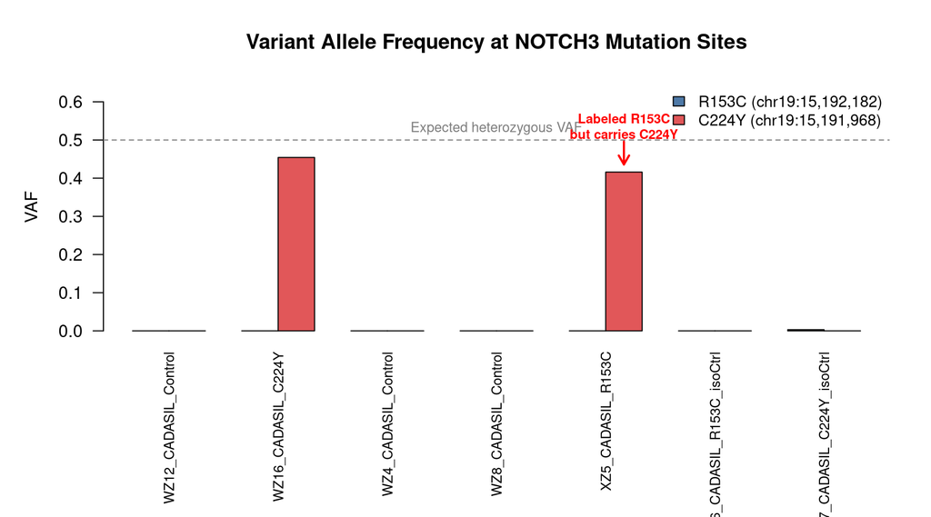

```r
vaf_r153c_col <- grep("R153C.*VAF", names(n3), value = TRUE)
vaf_c224y_col <- grep("C224Y.*VAF", names(n3), value = TRUE)

par(mar = c(9, 5, 4, 2))
bardata <- rbind(n3[[vaf_r153c_col]], n3[[vaf_c224y_col]])
colnames(bardata) <- n3$sample_name

colors <- c("#4e79a7", "#e15759")
bp <- barplot(bardata, beside = TRUE, col = colors,
              las = 2, ylim = c(0, 0.65), cex.names = 0.8,
              main = "Variant Allele Frequency at NOTCH3 Mutation Sites",
              ylab = "VAF")
legend("topright", legend = c("R153C (chr19:15,192,182)", "C224Y (chr19:15,191,968)"),
       fill = colors, bty = "n", cex = 0.9)
abline(h = 0.5, lty = 2, col = "gray50")
text(x = mean(bp[, 4]), y = 0.53, "Expected heterozygous VAF", col = "gray50", cex = 0.8)

# Annotate the discrepant sample
xz5_idx <- which(n3$sample_name == "XZ5_CADASIL_R153C")
arrows(bp[2, xz5_idx], n3[[vaf_c224y_col]][xz5_idx] + 0.08,
       bp[2, xz5_idx], n3[[vaf_c224y_col]][xz5_idx] + 0.02,
       col = "red", lwd = 2, length = 0.1)
text(bp[2, xz5_idx], n3[[vaf_c224y_col]][xz5_idx] + 0.12,
     "Labeled R153C\nbut carries C224Y", col = "red", cex = 0.75, font = 2)
```

## 6.3 Genome-wide Scan for R153C

# 7 Sample Provenance: Germline SNP Fingerprinting

## 7.1 Rationale

If XZ5 and WZ16 both carry C224Y, they may originate from the same patient. CRISPR correction of a single locus preserves the genome-wide germline SNP background, so true isogenic pairs should share nearly all heterozygous SNPs. By comparing the pattern of germline heterozygous SNPs across multiple chromosomes, we can verify which samples originate from the same individual.

## 7.2 Method

We performed samtools mpileup across **12 gene regions on 12 different chromosomes** for all 7 samples. Heterozygous positions were defined as sites with depth >= 15, VAF between 0.2–0.8, and at least 5 non-reference reads.

Pairwise similarity was quantified using the **Jaccard index:**

$$J(A, B) = \frac{|A \cap B|}{|A \cup B|}$$

High Jaccard (> 0.4) indicates the same individual. Low Jaccard (< 0.2) indicates different individuals.

## 7.3 Pairwise Concordance

The pairwise concordance data is loaded from `fingerprint_concordance.csv`, generated by `scripts/build_fingerprint_csv.sh` from the per-sample het_snps files produced by `scripts/sample_fingerprint.lsf` (Step 6).

```r
# Source: fingerprint_concordance.csv
# Generated by: scripts/build_fingerprint_csv.sh
# Which reads:   counts/fingerprint/*_het_snps.txt (from scripts/sample_fingerprint.lsf)
fp <- read.csv("fingerprint_concordance.csv", stringsAsFactors = FALSE)

# Shorten sample names for display
fp$sample_1 <- gsub("_CADASIL_", "_", fp$sample_1)
fp$sample_2 <- gsub("_CADASIL_", "_", fp$sample_2)

fp <- fp[order(-fp$jaccard), ]
fp$interpretation <- ifelse(fp$jaccard >= 0.4, "Same individual",
                     ifelse(fp$jaccard >= 0.2, "Possibly related",
                            "Different individuals"))

kable(fp, row.names = FALSE, align = "llrrrl", digits = 3,
      col.names = c("Sample 1", "Sample 2", "Shared Het SNPs", "Union",
                     "Jaccard Index", "Interpretation"),
      caption = "Pairwise Jaccard similarity loaded from fingerprint_concordance.csv (generated by build_fingerprint_csv.sh from sample_fingerprint.lsf output).") %>%
  kable_styling(bootstrap_options = c("striped", "hover", "condensed"),
                full_width = FALSE) %>%
  row_spec(which(fp$jaccard >= 0.4), background = "#f8d7da", bold = TRUE) %>%
  row_spec(which(fp$jaccard >= 0.2 & fp$jaccard < 0.4), background = "#fff3cd") %>%
  column_spec(5, bold = TRUE)
```

Pairwise Jaccard similarity loaded from fingerprint_concordance.csv (generated by build_fingerprint_csv.sh from sample_fingerprint.lsf output).

| Sample 1 | Sample 2 | Shared Het SNPs | Union | Jaccard Index | Interpretation |
| --- | --- | --- | --- | --- | --- |
| WZ16_C224Y | XZ5_R153C | 13 | 26 | 0.500 | Same individual |
| XZ5_R153C | XZ6_R153C_isoCtrl | 12 | 25 | 0.480 | Same individual |
| WZ4_Control | XZ7_C224Y_isoCtrl | 18 | 39 | 0.462 | Same individual |
| WZ16_C224Y | XZ6_R153C_isoCtrl | 7 | 21 | 0.333 | Possibly related |
| XZ6_R153C_isoCtrl | XZ7_C224Y_isoCtrl | 9 | 39 | 0.231 | Possibly related |
| WZ12_Control | WZ4_Control | 8 | 44 | 0.182 | Different individuals |
| XZ5_R153C | XZ7_C224Y_isoCtrl | 9 | 50 | 0.180 | Different individuals |
| WZ12_Control | XZ7_C224Y_isoCtrl | 9 | 56 | 0.161 | Different individuals |
| WZ8_Control | XZ6_R153C_isoCtrl | 3 | 22 | 0.136 | Different individuals |
| WZ12_Control | WZ16_C224Y | 5 | 40 | 0.125 | Different individuals |
| WZ16_C224Y | WZ8_Control | 3 | 24 | 0.125 | Different individuals |
| WZ12_Control | XZ5_R153C | 5 | 49 | 0.102 | Different individuals |
| WZ4_Control | XZ5_R153C | 4 | 42 | 0.095 | Different individuals |
| WZ4_Control | XZ6_R153C_isoCtrl | 3 | 32 | 0.094 | Different individuals |
| WZ8_Control | XZ5_R153C | 3 | 33 | 0.091 | Different individuals |
| WZ16_C224Y | WZ4_Control | 3 | 34 | 0.088 | Different individuals |
| WZ12_Control | XZ6_R153C_isoCtrl | 3 | 40 | 0.075 | Different individuals |
| WZ16_C224Y | XZ7_C224Y_isoCtrl | 3 | 47 | 0.064 | Different individuals |
| WZ4_Control | WZ8_Control | 2 | 32 | 0.062 | Different individuals |
| WZ12_Control | WZ8_Control | 1 | 41 | 0.024 | Different individuals |
| WZ8_Control | XZ7_C224Y_isoCtrl | 1 | 46 | 0.022 | Different individuals |

## 7.4 Concordance Heatmap

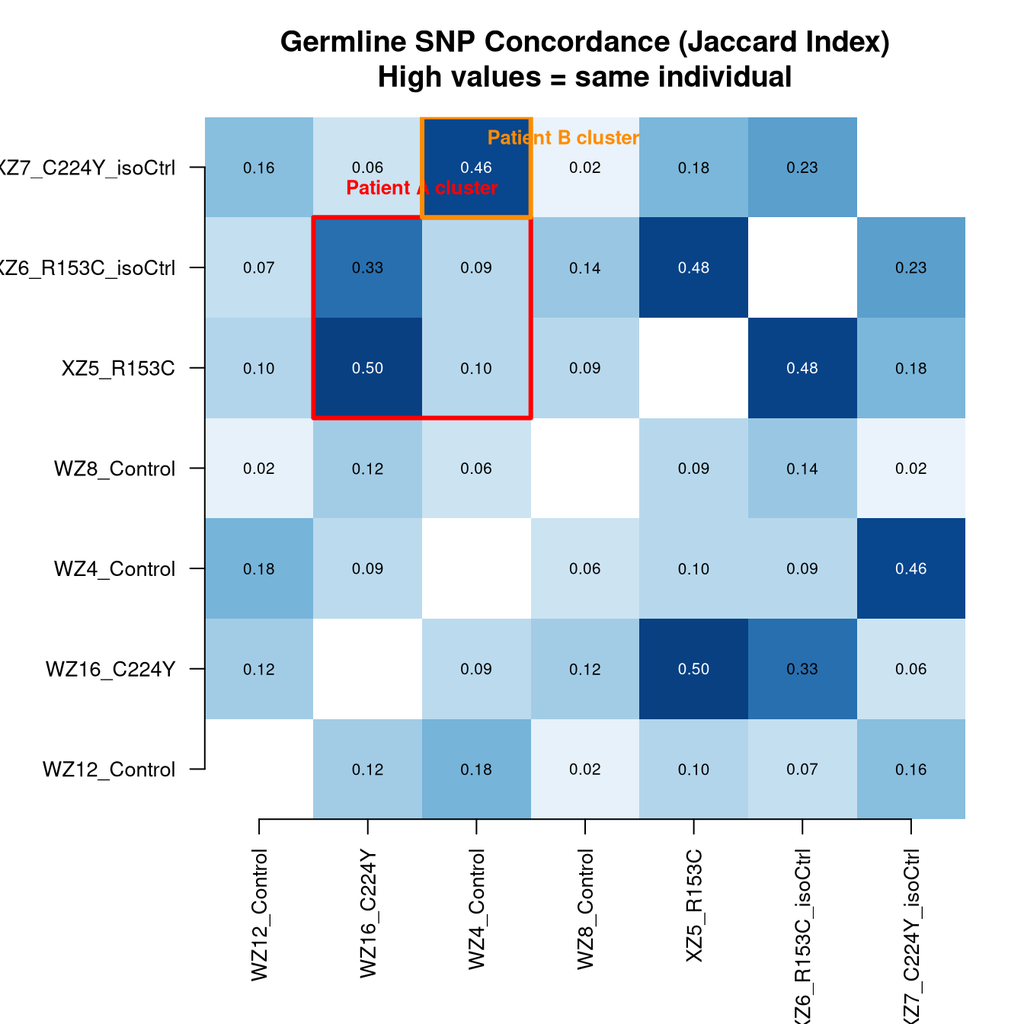

```r
# Build heatmap matrix programmatically from fingerprint_concordance.csv
fp_raw <- read.csv("fingerprint_concordance.csv", stringsAsFactors = FALSE)
all_samples <- sort(unique(c(fp_raw$sample_1, fp_raw$sample_2)))

# Shorten names for display
short_name <- function(x) gsub("_CADASIL", "", x)
samples_short <- short_name(all_samples)

jmat <- matrix(0, nrow = length(all_samples), ncol = length(all_samples),
               dimnames = list(samples_short, samples_short))
diag(jmat) <- 1

for (i in seq_len(nrow(fp_raw))) {
  s1 <- short_name(fp_raw$sample_1[i])
  s2 <- short_name(fp_raw$sample_2[i])
  jmat[s1, s2] <- fp_raw$jaccard[i]
  jmat[s2, s1] <- fp_raw$jaccard[i]
}

col_palette <- colorRampPalette(c("#f7fbff", "#6baed6", "#08519c", "#08306b"))(100)
par(mar = c(7, 7, 4, 2))
image(1:7, 1:7, jmat, col = col_palette, zlim = c(0, 0.6),
      xlab = "", ylab = "", axes = FALSE,
      main = "Germline SNP Concordance (Jaccard Index)\nHigh values = same individual")
axis(1, at = 1:7, labels = samples_short, las = 2, cex.axis = 0.85)
axis(2, at = 1:7, labels = samples_short, las = 2, cex.axis = 0.85)

for (i in 1:7) {
  for (j in 1:7) {
    if (i != j) {
      text(i, j, sprintf("%.2f", jmat[i, j]),
           cex = 0.65, col = ifelse(jmat[i, j] > 0.35, "white", "black"))
    }
  }
}

# Cluster boxes
rect(1.5, 4.5, 3.5, 6.5, border = "red", lwd = 3)
text(2.5, 6.8, "Patient A cluster", col = "red", cex = 0.8, font = 2)
rect(2.5, 6.5, 3.5, 7.5, border = "darkorange", lwd = 3)
text(3.8, 7.3, "Patient B cluster", col = "darkorange", cex = 0.8, font = 2)
```

## 7.5 Key Observations

#### Finding 1: WZ16 and XZ5 are from the same patient

Jaccard = 0.500 (highest of all pairs). Both carry C224Y at chr19:15,191,968. The study has **one CADASIL mutation, not two**.

#### Finding 2: XZ5 and XZ6 are confirmed isogenic

Jaccard = 0.480. XZ6 is the CRISPR-corrected line from the same patient as XZ5/WZ16. However, it corrects **C224Y**, not R153C as labeled.

#### Finding 3: XZ7 pairs with WZ4, not WZ16

Jaccard(WZ4, XZ7) = 0.462, but Jaccard(WZ16, XZ7) = **0.064**. XZ7 is **not** an isogenic control for WZ16. It appears to be derived from the WZ4 wild-type background, making it an additional wild-type control rather than a CRISPR-corrected C224Y line.

# 8 Revised Sample Relationships

```r
revised <- data.frame(
  Sample = c("WZ12_CADASIL_Control", "WZ4_CADASIL_Control", "WZ8_CADASIL_Control",
             "WZ16_CADASIL_C224Y", "XZ5_CADASIL_R153C",
             "XZ6_CADASIL_R153C_isoCtrl", "XZ7_CADASIL_C224Y_isoCtrl"),
  Reported_Genotype = c("wild type", "wild type", "wild type",
                        "p.C224Y", "p.R153C", "corrected R153C", "corrected C224Y"),
  Observed_Genotype = c("wild type", "wild type", "wild type",
                        "p.C224Y", "p.C224Y", "corrected (C224Y)", "wild type"),
  Reported_Pair = c("--", "--", "--",
                    "WZ16 - XZ7", "XZ5 - XZ6", "XZ5 - XZ6", "WZ16 - XZ7"),
  Observed_Pair = c("--", "WZ4 - XZ7", "--",
                    "WZ16 - XZ5 - XZ6", "WZ16 - XZ5 - XZ6",
                    "WZ16 - XZ5 - XZ6", "WZ4 - XZ7"),
  Discrepancy = c("None", "Gains isogenic pair", "None",
                  "Loses XZ7 pair; gains XZ5",
                  "Wrong mutation; same patient as WZ16",
                  "Corrects C224Y not R153C",
                  "Not isogenic C224Y; WT from WZ4 background")
)

kable(revised, align = "llllll",
      col.names = c("Sample", "Reported Genotype", "Observed Genotype",
                     "Reported Pair", "Observed Pair", "Discrepancy"),
      caption = "Comparison of reported vs. observed sample relationships. Discrepant entries are highlighted.") %>%
  kable_styling(bootstrap_options = c("striped", "hover", "condensed"),
                full_width = FALSE) %>%
  row_spec(which(revised$Discrepancy != "None"), background = "#fff3cd") %>%
  column_spec(6, bold = TRUE, color = "#dc3545")
```

Comparison of reported vs. observed sample relationships. Discrepant entries are highlighted.

| Sample | Reported Genotype | Observed Genotype | Reported Pair | Observed Pair | Discrepancy |
| --- | --- | --- | --- | --- | --- |
| WZ12_CADASIL_Control | wild type | wild type | – | – | None |
| WZ4_CADASIL_Control | wild type | wild type | – | WZ4 - XZ7 | Gains isogenic pair |
| WZ8_CADASIL_Control | wild type | wild type | – | – | None |
| WZ16_CADASIL_C224Y | p.C224Y | p.C224Y | WZ16 - XZ7 | WZ16 - XZ5 - XZ6 | Loses XZ7 pair; gains XZ5 |
| XZ5_CADASIL_R153C | p.R153C | p.C224Y | XZ5 - XZ6 | WZ16 - XZ5 - XZ6 | Wrong mutation; same patient as WZ16 |
| XZ6_CADASIL_R153C_isoCtrl | corrected R153C | corrected (C224Y) | XZ5 - XZ6 | WZ16 - XZ5 - XZ6 | Corrects C224Y not R153C |
| XZ7_CADASIL_C224Y_isoCtrl | corrected C224Y | wild type | WZ16 - XZ7 | WZ4 - XZ7 | Not isogenic C224Y; WT from WZ4 background |

**Revised Sample Relationships:**  
Patient A (C224Y):  
WZ16_C224Y (mutant) —— XZ5 (mutant, R153C → C224Y) —— XZ6 (isogenic ctrl)  
*All three from the same individual. Both WZ16 and XZ5 carry C224Y.*  
*XZ6 is CRISPR-corrected C224Y (confirmed: VAF = 0.00).*

Patient B (wild type):  
WZ4_Control —— XZ7 (C224Y isogenic ctrl → additional WT control)  
*Same individual. Neither carries a NOTCH3 mutation.*

Independent controls:  
WZ12_Control (Patient C, wild type)  
WZ8_Control (Patient D, wild type)

# 9 Impact on Study Conclusions

#### What remains valid

- All CADASIL vs. control comparisons remain valid — both mutation samples are true C224Y heterozygotes, and controls are true wild-type or CRISPR-corrected.
- Gene expression patterns and pathway analyses comparing mutant to control NC-VSMCs are unaffected.
- CRISPR correction is confirmed at the C224Y locus: isogenic controls show VAF = 0.00.

#### What requires revision

# 10 Gene Expression Overview

```r
# Source: genes_of_interest_counts.csv, sample_metadata.csv
# Generated by: scripts/03_build_matrices.py
# Input: featureCounts gene_counts.txt filtered to CADASIL-relevant Ensembl IDs
goi <- read.csv("genes_of_interest_counts.csv", check.names = FALSE)
meta <- read.csv("sample_metadata.csv", check.names = FALSE)
```

```r
goi_display <- goi
goi_display$gene_id <- gsub("^.*\\|", "", goi_display$gene_id)
names(goi_display)[1] <- "Gene"

kable(goi_display, align = c("l", rep("r", ncol(goi_display) - 1)),
      format.args = list(big.mark = ","),
      caption = "Raw counts for CADASIL-relevant genes. NOTCH3 expression (4,865--29,546 counts) provides high confidence in the variant calling results.") %>%
  kable_styling(bootstrap_options = c("striped", "hover", "condensed"),
                full_width = FALSE, font_size = 12)
```

Raw counts for CADASIL-relevant genes. NOTCH3 expression (4,865–29,546 counts) provides high confidence in the variant calling results.

| Gene | WZ12_CADASIL_Control | WZ16_CADASIL_C224Y | WZ4_CADASIL_Control | WZ8_CADASIL_Control | XZ5_CADASIL_R153C | XZ6_CADASIL_R153C_isoCtrl | XZ7_CADASIL_C224Y_isoCtrl |
| --- | --- | --- | --- | --- | --- | --- | --- |
| JUN | 2,741 | 1,336 | 2,345 | 2,074 | 1,545 | 3,569 | 2,229 |
| TAGLN | 1,994 | 2,934 | 882 | 5,605 | 6,492 | 519 | 580 |
| FN1 | 781,447 | 644,132 | 359,902 | 1,007,867 | 762,954 | 1,697,979 | 765,053 |
| KDR | 339 | 515 | 135 | 271 | 1,859 | 351 | 342 |
| ALB | 1 | 0 | 1 | 4 | 4 | 3 | 2 |
| VEGFA | 513 | 388 | 835 | 721 | 621 | 526 | 394 |
| ACTA2 | 36,423 | 3,706 | 8,886 | 33,272 | 25,329 | 13,663 | 27,143 |
| CNN1 | 0 | 5 | 3 | 20 | 2 | 1 | 0 |
| VEGFB | 1,529 | 972 | 776 | 824 | 1,312 | 683 | 702 |
| FLT1 | 13 | 152 | 57 | 208 | 72 | 65 | 217 |
| FOS | 2,072 | 338 | 132 | 158 | 258 | 85 | 232 |
| SERPINA3 | 0 | 2 | 0 | 0 | 3 | 0 | 0 |
| NEDD4 | 1,793 | 1,123 | 2,044 | 1,457 | 2,051 | 1,778 | 1,567 |
| MYH11 | 869 | 23 | 36 | 248 | 379 | 94 | 149 |
| MYOCD | 3,526 | 1,839 | 2,305 | 2,824 | 1,414 | 2,768 | 2,213 |
| NOTCH3 | 11,581 | 10,969 | 4,865 | 13,413 | 29,546 | 4,872 | 18,229 |

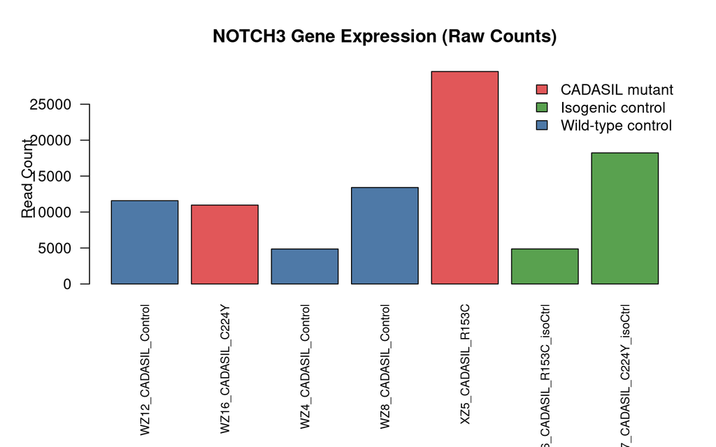

```r
notch3_row <- grep("NOTCH3", goi$gene_id)
if (length(notch3_row) > 0) {
  counts <- as.numeric(goi[notch3_row, -1])
  sample_names <- names(goi)[-1]

  # Color by group
  sample_colors <- ifelse(grepl("C224Y$|R153C$", sample_names), "#e15759",
                   ifelse(grepl("isoCtrl", sample_names), "#59a14f", "#4e79a7"))

  par(mar = c(9, 5, 4, 2))
  bp <- barplot(counts, names.arg = sample_names, col = sample_colors,
                las = 2, cex.names = 0.8,
                main = "NOTCH3 Gene Expression (Raw Counts)",
                ylab = "Read Count")
  legend("topright",
         legend = c("CADASIL mutant", "Isogenic control", "Wild-type control"),
         fill = c("#e15759", "#59a14f", "#4e79a7"), bty = "n")
}
```

*Report generated on 2026-04-14. All analysis scripts and raw outputs available upon request.*